# Getting Started with R/Rstudio

Michael McIsaac

## Read in the data

In order to read the data into R, you need to enter the path to the dataset.

You should create a new “Project” in RStudio and, once you download your .csv file, you should place that dataset inside your project folder (ideally in a sub-folder called something like “data”). That way, your path could be relative to project directory. Alternately, you could use something like `file.choose()` to bring up a GUI that allows you to point and click on the file, but this means you need to point and click everytime you re-run the code and your code would not be reproducible (someone else couldn’t run your Rmd file and get the same output).

```r
# Now read in the data from the defined path:
senic = read_csv(here("data", "senic.csv"))
```

## Regression Modelling

Run a linear model based on the data set that we called “senic” and summarize the model fit

```r
model_infection = lm(length_of_stay~infection_risk, data=senic)
msummary(model_infection)
```

```
##                Estimate Std. Error t value Pr(>|t|)
## (Intercept)      6.4566     0.6822   9.465 1.21e-14 ***
## infection_risk   0.7582     0.1444   5.249 1.26e-06 ***
##
## Residual standard error: 1.765 on 79 degrees of freedom
## Multiple R-squared:  0.2586, Adjusted R-squared:  0.2492
## F-statistic: 27.55 on 1 and 79 DF,  p-value: 1.255e-06
```

Find the confidence intervals for the parameters in the model

```r
confint(model_infection)
```

```
##                   2.5 %   97.5 %
## (Intercept)    5.098780 7.814503
## infection_risk 0.470703 1.045738
```

Find the pointwise confidence intervals for a few specific predictions

```r
predict(model_infection, newdata=data.frame(infection_risk=c(5, 5.5, 6)), interval="confidence", level=.95)
```

```
##        fit       lwr      upr
## 1 10.24774  9.834141 10.66135
## 2 10.62685 10.146096 11.10761
## 3 11.00597 10.429317 11.58261
```

Find the pointwise prediction intervals for a few specific predictions

```r
predict(model_infection, newdata=data.frame(infection_risk=c(5, 5.5, 6)), interval="prediction", level=.95)
```

```
##        fit      lwr      upr
## 1 10.24774 6.711222 13.78427
## 2 10.62685 7.081851 14.17186
## 3 11.00597 7.446689 14.56524
```

Find the Working-Hotelling confidence band values for a few specific predictions

```r
predict_adjust(model_infection, newdata=data.frame(infection_risk=c(5, 5.5, 6)), interval="confidence", method="wh", level=.95)
```

```
##
## Working-Hotelling-adjusted confidence intervals
##
## Family-wise confidence level of at least 0.95
##
##        fit       lwr      upr
## 1 10.24774  9.729319 10.76617
## 2 10.62685 10.024255 11.22945
## 3 11.00597 10.283175 11.72876
```

Find the Bonferroni simultaneous confidence interval values for a few specific predictions

```r
predict_adjust(model_infection, newdata=data.frame(infection_risk=c(5, 5.5, 6)), interval="confidence", method="bonferroni", level=.95)
```

```
##
## Bonferroni-adjusted confidence intervals
##
## Family-wise confidence level of at least 0.95
##
##        fit       lwr      upr
## 1 10.24774  9.739475 10.75601
## 2 10.62685 10.036060 11.21765
## 3 11.00597 10.297334 11.71460
```

Run a linear model based on the data set that we called “senic”, but only the parts where “region” has the value “NC”

```r
model_infection_nc = lm(length_of_stay~infection_risk, data=senic, subset=(region=="NC"))
msummary(model_infection_nc)
```

```
##                Estimate Std. Error t value Pr(>|t|)
## (Intercept)      8.0052     0.7222  11.085 1.79e-09 ***
## infection_risk   0.4161     0.1528   2.724   0.0139 *
##
## Residual standard error: 1.052 on 18 degrees of freedom
## Multiple R-squared:  0.2919, Adjusted R-squared:  0.2525
## F-statistic: 7.419 on 1 and 18 DF,  p-value: 0.01393
```

Run a linear model based on the data set that we called “senic”, but with the “infection_risk” variable centered at 0:

```r
model_infection_centered = lm(length_of_stay~I(infection_risk-mean(infection_risk)), data=senic)
msummary(model_infection_centered)
```

```
##                                          Estimate Std. Error t value Pr(>|t|)
## (Intercept)                                9.8864     0.1961  50.425  < 2e-16
## I(infection_risk - mean(infection_risk))   0.7582     0.1444   5.249 1.26e-06
##
## (Intercept)                              ***
## I(infection_risk - mean(infection_risk)) ***
##
## Residual standard error: 1.765 on 79 degrees of freedom
## Multiple R-squared:  0.2586, Adjusted R-squared:  0.2492
## F-statistic: 27.55 on 1 and 79 DF,  p-value: 1.255e-06
```

Run a linear model based on the data set that we called “senic”, but with both “infection_risk” and “age” as predictor variables

```r
model_infection_age = lm(length_of_stay~infection_risk + age, data=senic)
msummary(model_infection_age)
```

```
##                Estimate Std. Error t value Pr(>|t|)
## (Intercept)     1.89711    2.36351   0.803   0.4246
## infection_risk  0.75447    0.14175   5.322 9.56e-07 ***
## age             0.08599    0.04275   2.012   0.0477 *
##
## Residual standard error: 1.731 on 78 degrees of freedom
## Multiple R-squared:  0.2951, Adjusted R-squared:  0.2771
## F-statistic: 16.33 on 2 and 78 DF,  p-value: 1.191e-06
```

Find the confidence interval for a specific prediction from the multiple linear regression model (infection risk is 5, age is 50):

```r
predict(model_infection_age, newdata=data.frame(infection_risk=5, age=50), interval="confidence", level=.95)
```

```
##        fit      lwr      upr
## 1 9.969085 9.478324 10.45985
```

```r
predict(model_infection, newdata=data.frame(infection_risk=c(5, 6), age=c(50, 40)), interval="prediction", level=.95)
```

```
##        fit      lwr      upr
## 1 10.24774 6.711222 13.78427
## 2 11.00597 7.446689 14.56524
```

## Other potentially useful code and functions for future assignments

Create an ANOVA table

```r
anova(model_infection)
```

```
## Analysis of Variance Table
##
## Response: length_of_stay
##                Df  Sum Sq Mean Sq F value    Pr(>F)
## infection_risk  1  85.789  85.789  27.553 1.255e-06 ***
## Residuals      79 245.978   3.114
## ---
## Signif. codes:  0 '***' 0.001 '**' 0.01 '*' 0.05 '.' 0.1 ' ' 1
```

Find R^2

```r
summary(model_infection)$r.squared
```

```
## [1] 0.2585832
```

Calculate Pearson correlation

```r
mosaic::cor.test(length_of_stay~infection_risk, data=senic, method="pearson")
```

```
##
##  Pearson's product-moment correlation
##
## data:  length_of_stay and infection_risk
## t = 5.2491, df = 79, p-value = 1.255e-06
## alternative hypothesis: true correlation is not equal to 0
## 95 percent confidence interval:
##  0.3264028 0.6542201
## sample estimates:
##       cor
## 0.5085107
```

Calculate Spearman correlation

```r
mosaic::cor.test(length_of_stay~infection_risk, data=senic, method="spearman", exact=FALSE)
```

```
##
##  Spearman's rank correlation rho
##
## data:  length_of_stay and infection_risk
## S = 40890, p-value = 2.184e-07
## alternative hypothesis: true rho is not equal to 0
## sample estimates:
##       rho
## 0.5382847
```

Conduct a General Linear Test

```r
model_infection_reduced = lm(length_of_stay~1, data=senic)
anova(model_infection_reduced, model_infection)
```

```
## Analysis of Variance Table
##
## Model 1: length_of_stay ~ 1
## Model 2: length_of_stay ~ infection_risk
##   Res.Df    RSS Df Sum of Sq      F    Pr(>F)
## 1     80 331.77
## 2     79 245.98  1    85.789 27.553 1.255e-06 ***
## ---
## Signif. codes:  0 '***' 0.001 '**' 0.01 '*' 0.05 '.' 0.1 ' ' 1
```

Test for Lack of Fit

```r
pacman::p_load_gh("cran/alr3")
model_infection_full = lm(length_of_stay~factor(infection_risk), data=senic)
anova(model_infection, model_infection_full)
```

```
## Analysis of Variance Table
##
## Model 1: length_of_stay ~ infection_risk
## Model 2: length_of_stay ~ factor(infection_risk)
##   Res.Df     RSS Df Sum of Sq      F   Pr(>F)
## 1     79 245.978
## 2     40  67.602 39    178.38 2.7063 0.001123 **
## ---
## Signif. codes:  0 '***' 0.001 '**' 0.01 '*' 0.05 '.' 0.1 ' ' 1
```

```r
alr3::pureErrorAnova(model_infection)
```

```
## Analysis of Variance Table
##
## Response: length_of_stay
##                Df  Sum Sq Mean Sq F value    Pr(>F)
## infection_risk  1  85.789  85.789 50.7615 1.258e-08 ***
## Residuals      79 245.978   3.114
##  Lack of fit   39 178.376   4.574  2.7063  0.001123 **
##  Pure Error    40  67.602   1.690
## ---
## Signif. codes:  0 '***' 0.001 '**' 0.01 '*' 0.05 '.' 0.1 ' ' 1
```

Create Residual plots

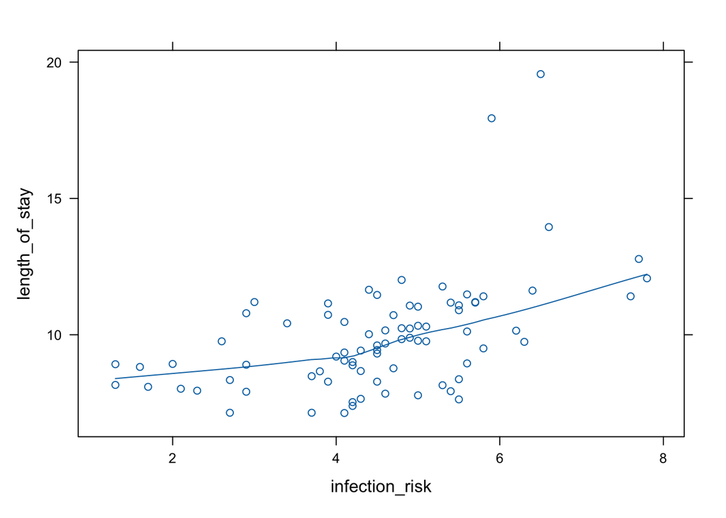

```r
xyplot(length_of_stay~infection_risk, data=senic,  type=c("p", "smooth"))
```

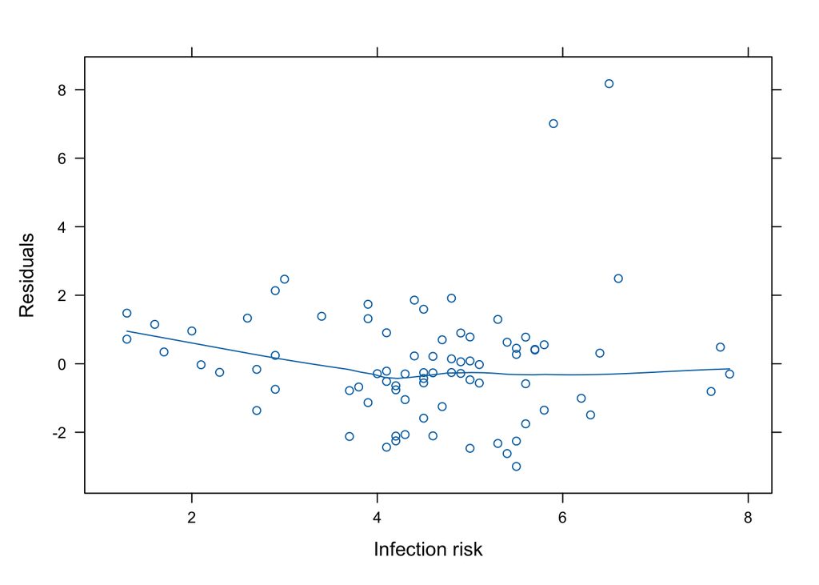

```r
xyplot(resid(model_infection)~senic$infection_risk, ylab="Residuals", xlab="Infection risk", type=c("p", "smooth"))
```

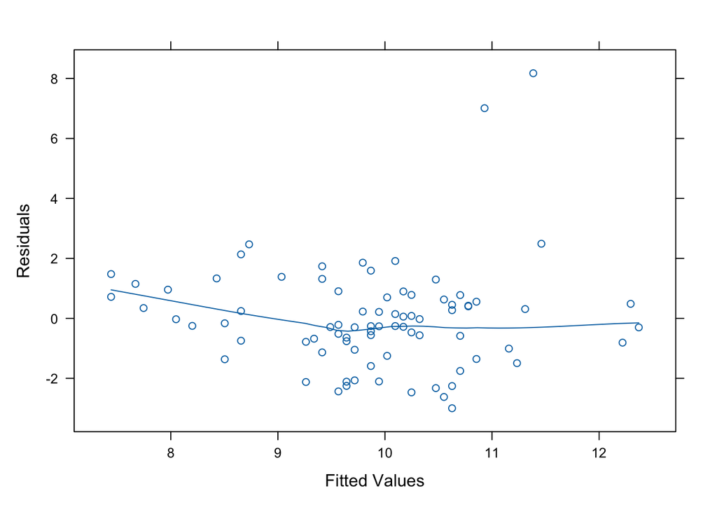

```r
xyplot(resid(model_infection)~predict(model_infection), ylab="Residuals", xlab="Fitted Values", type=c("p", "smooth"))
```

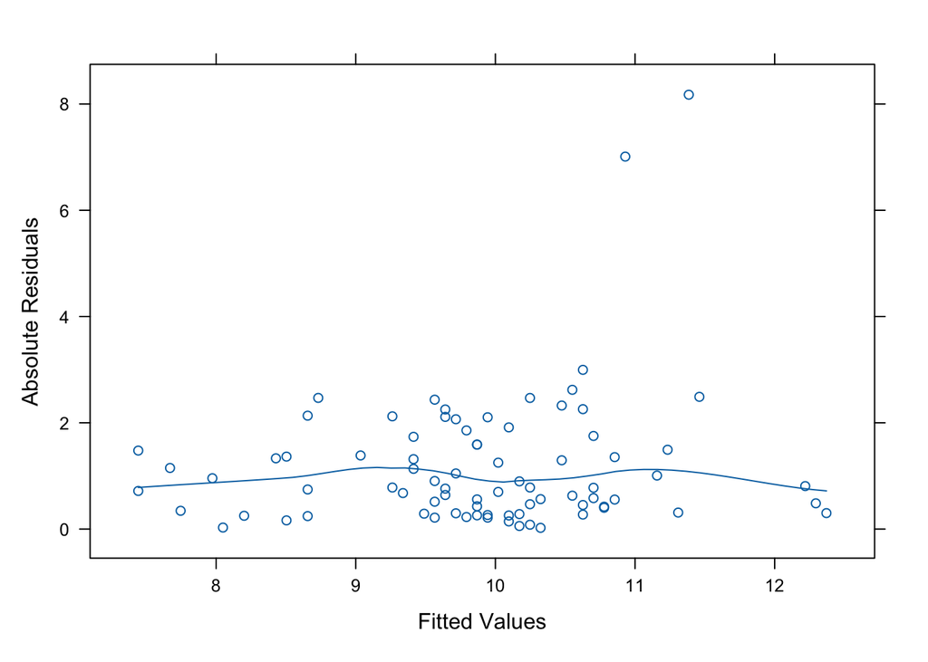

```r
xyplot(abs(resid(model_infection))~predict(model_infection), ylab="Absolute Residuals", xlab="Fitted Values", type=c("p", "smooth"))
```

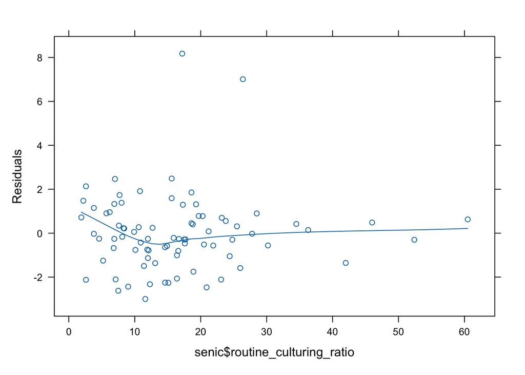

```r
xyplot(resid(model_infection)~senic$routine_culturing_ratio, ylab="Residuals", type=c("p", "smooth"))
```

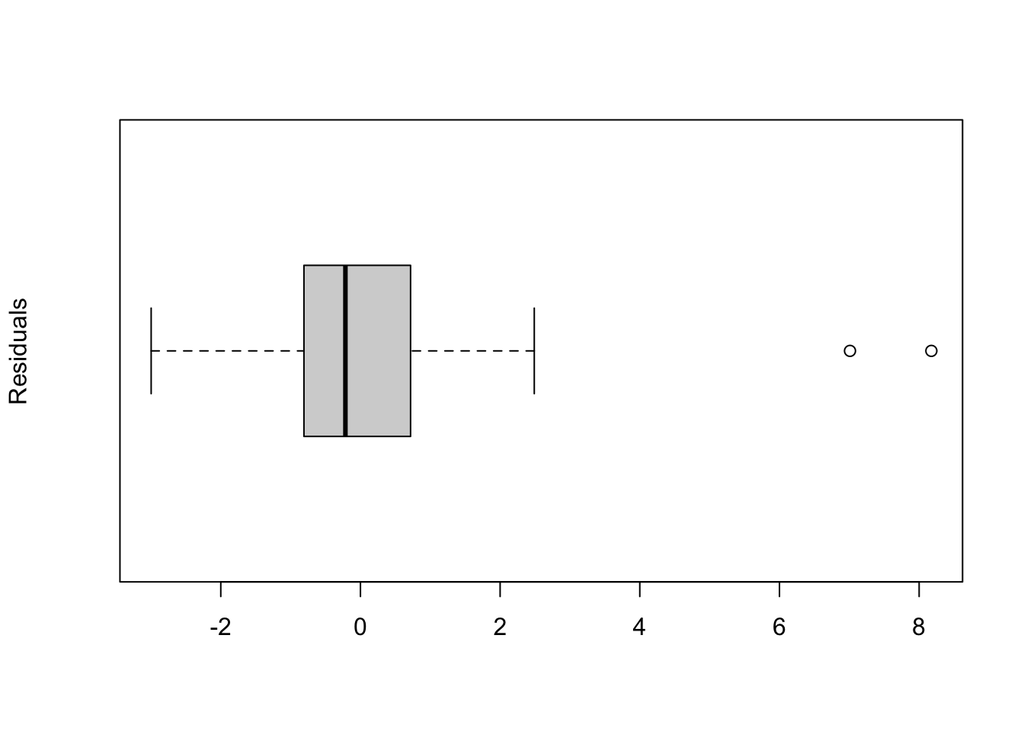

```r
boxplot(resid(model_infection), ylab="Residuals", horizontal=TRUE)
```

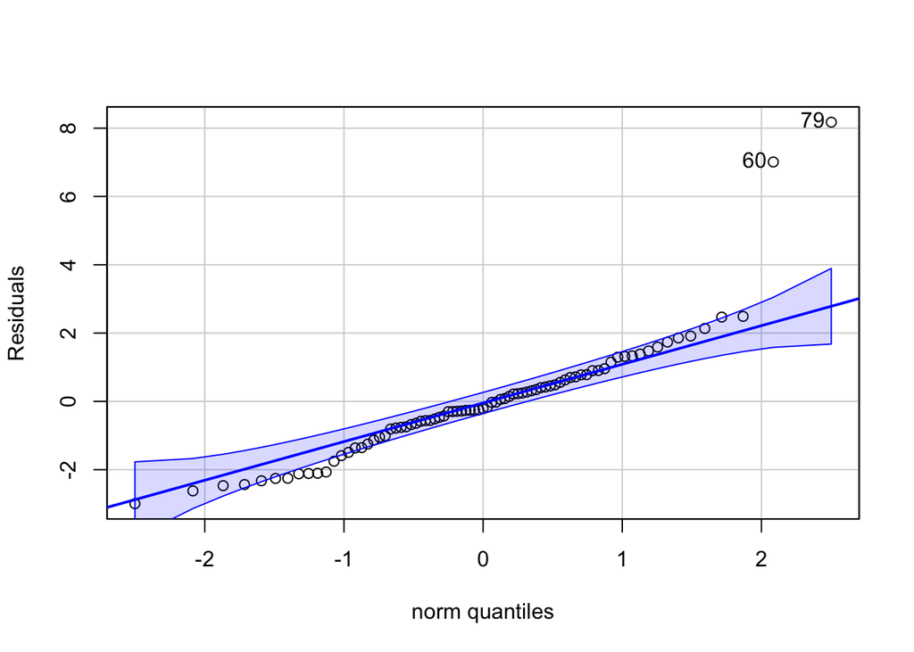

```
## [1] 79 60
```

```r
qqPlot(resid(model_infection), ylab="Residuals")
```

Box Cox Plot

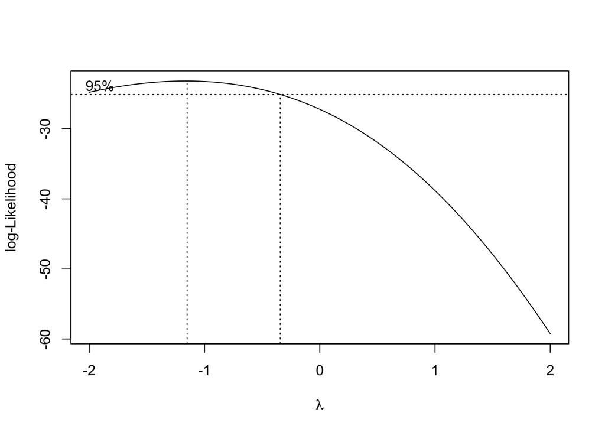

```r
MASS::boxcox(model_infection)
```

LOWESS curve

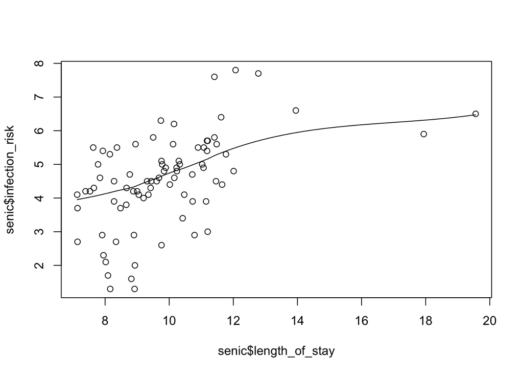

```r
scatter.smooth(senic$length_of_stay, senic$infection_risk)
```

5 number summary

```r
summary(senic$infection_risk)
```

```
##    Min. 1st Qu.  Median    Mean 3rd Qu.    Max.
##   1.300   3.900   4.600   4.523   5.400   7.800
```

Change the order of a categorical (factor) variable (note that the first category listed is the reference category)

```r
senic$region = factor(senic$region, levels=c("W", "NE", "NC", "S"))
```

## Below is code that will likely be useful in the wrap-up assignment for Chapter 9:

Remove unwanted predictors

```r
senic = senic[, -c(7,8)]
```

Transform the outcome

```r
senic$length_of_stay = log10(senic$length_of_stay)
```

Separate the data set into a “training” set and a “validation” set

```r
train = senic[41:110, ]
validation = senic[1:40, ]
```

Set up a first-order linear regression model with all predictor variables

```r
stay_model = lm(length_of_stay~., data=train)
```

Calculate various model selection critiria for all possible models; retain only the 3 best models of each size (i.e., for each number of predictor variables)

```r
subsets = regsubsets(formula(stay_model), data=model.frame(stay_model), nvmax=10, nbest= 3)
```

Produce a data frame that displays the model selection criteria in an easier to read manner

```r
model_selection_criteria = data.frame(with(summary(subsets), cbind(p = as.numeric(rownames(which)), which, rss, rsq, adjr2, cp, bic)))
```

Order the models based on different criteria

```r
model_selection_criteria[order(model_selection_criteria$bic),]
```

```
##      p X.Intercept. age infection_risk routine_culturing_ratio
## X4   4            1   1              0                       1
## X3   3            1   0              1                       0
## X5   5            1   1              0                       1
## X4.1 4            1   0              1                       0
## X3.1 3            1   0              1                       0
## X3.2 3            1   0              1                       0
## X2   2            1   0              1                       0
## X4.2 4            1   1              1                       0
## X5.1 5            1   1              1                       1
## X5.2 5            1   1              1                       0
## X6   6            1   1              0                       1
## X2.1 2            1   0              0                       0
## X6.1 6            1   1              1                       1
## X2.2 2            1   0              0                       0
## X6.2 6            1   1              0                       1
## X1   1            1   0              1                       0
## X7   7            1   1              1                       1
## X7.1 7            1   1              0                       1
## X7.2 7            1   1              1                       1
## X1.1 1            1   0              0                       0
## X8   8            1   1              1                       1
## X1.2 1            1   0              0                       0
##      routine_xray_ratio number_of_beds average_daily_census number_of_nurses
## X4                    0              1                    1                0
## X3                    0              1                    1                0
## X5                    0              1                    1                0
## X4.1                  1              1                    1                0
## X3.1                  1              0                    1                0
## X3.2                  0              0                    1                1
## X2                    0              0                    1                0
## X4.2                  0              1                    1                0
## X5.1                  0              1                    1                0
## X5.2                  1              1                    1                0
## X6                    0              1                    1                1
## X2.1                  1              0                    1                0
## X6.1                  0              1                    1                0
## X2.2                  0              1                    1                0
## X6.2                  1              1                    1                0
## X1                    0              0                    0                0
```

[output cut: 14 more lines]

```
## X4.2                  0 0.1632603 0.5156942 0.4618825  6.796451 -11.158730
## X5.1                  0 0.1497131 0.5558815 0.4924360  5.660132 -10.996788
## X5.2                  0 0.1541011 0.5428648 0.4775598  6.675988  -9.812390
## X6                    1 0.1411168 0.5813822 0.5075085  5.669995  -9.707669
## X2.1                  0 0.2053789 0.3907509 0.3586851 12.547348  -9.175932
## X6.1                  1 0.1430352 0.5756914 0.5008134  6.114122  -9.154056
## X2.2                  0 0.2060891 0.3886441 0.3564674 12.711767  -9.034397
## X6.2                  1 0.1449396 0.5700419 0.4941670  6.555017  -8.611767
## X1                    0 0.2353343 0.3018894 0.2839892 17.482319  -7.307345
## X7                    1 0.1383994 0.5894433 0.5023555  7.040887  -6.791312
## X7.1                  1 0.1410608 0.5815483 0.4927859  7.657029  -6.010373
## X7.2                  1 0.1421902 0.5781980 0.4887248  7.918499  -5.683412
## X1.1                  0 0.2454700 0.2718223 0.2531510 19.828838  -5.578470
## X8                    1 0.1382228 0.5899672 0.4874590  9.000000  -3.130094
## X1.2                  0 0.2744094 0.1859745 0.1651021 26.528611  -1.009165
```

```r
model_selection_criteria[order(model_selection_criteria$rsq),]
```

```
##      p X.Intercept. age infection_risk routine_culturing_ratio
## X1.2 1            1   0              0                       0
## X1.1 1            1   0              0                       0
## X1   1            1   0              1                       0
## X2.2 2            1   0              0                       0
## X2.1 2            1   0              0                       0
## X2   2            1   0              1                       0
## X3.2 3            1   0              1                       0
## X3.1 3            1   0              1                       0
## X3   3            1   0              1                       0
## X4.2 4            1   1              1                       0
## X4.1 4            1   0              1                       0
## X4   4            1   1              0                       1
## X5.2 5            1   1              1                       0
## X5.1 5            1   1              1                       1
## X5   5            1   1              0                       1
## X6.2 6            1   1              0                       1
## X6.1 6            1   1              1                       1
## X7.2 7            1   1              1                       1
## X6   6            1   1              0                       1
## X7.1 7            1   1              0                       1
## X7   7            1   1              1                       1
## X8   8            1   1              1                       1
##      routine_xray_ratio number_of_beds average_daily_census number_of_nurses
## X1.2                  0              1                    0                0
## X1.1                  0              0                    1                0
## X1                    0              0                    0                0
## X2.2                  0              1                    1                0
## X2.1                  1              0                    1                0
## X2                    0              0                    1                0
## X3.2                  0              0                    1                1
## X3.1                  1              0                    1                0
## X3                    0              1                    1                0
## X4.2                  0              1                    1                0
## X4.1                  1              1                    1                0
## X4                    0              1                    1                0
## X5.2                  1              1                    1                0
## X5.1                  0              1                    1                0
## X5                    0              1                    1                0
## X6.2                  1              1                    1                0
```

[output cut: 14 more lines]

```
## X3.1                  0 0.1757699 0.4785849 0.4363080  7.692557 -11.845273
## X3                    0 0.1730079 0.4867785 0.4451659  7.053109 -12.494667
## X4.2                  0 0.1632603 0.5156942 0.4618825  6.796451 -11.158730
## X4.1                  0 0.1601532 0.5249115 0.4721238  6.077114 -11.946557
## X4                    0 0.1579767 0.5313679 0.4792976  5.573238 -12.507566
## X5.2                  0 0.1541011 0.5428648 0.4775598  6.675988  -9.812390
## X5.1                  0 0.1497131 0.5558815 0.4924360  5.660132 -10.996788
## X5                    1 0.1454744 0.5684555 0.5068063  4.678826 -12.174339
## X6.2                  1 0.1449396 0.5700419 0.4941670  6.555017  -8.611767
## X6.1                  1 0.1430352 0.5756914 0.5008134  6.114122  -9.154056
## X7.2                  1 0.1421902 0.5781980 0.4887248  7.918499  -5.683412
## X6                    1 0.1411168 0.5813822 0.5075085  5.669995  -9.707669
## X7.1                  1 0.1410608 0.5815483 0.4927859  7.657029  -6.010373
## X7                    1 0.1383994 0.5894433 0.5023555  7.040887  -6.791312
## X8                    1 0.1382228 0.5899672 0.4874590  9.000000  -3.130094
```

```r
model_selection_criteria[order(model_selection_criteria$adjr2),]
```

```
##      p X.Intercept. age infection_risk routine_culturing_ratio
## X1.2 1            1   0              0                       0
## X1.1 1            1   0              0                       0
## X1   1            1   0              1                       0
## X2.2 2            1   0              0                       0
## X2.1 2            1   0              0                       0
## X2   2            1   0              1                       0
## X3.2 3            1   0              1                       0
## X3.1 3            1   0              1                       0
## X3   3            1   0              1                       0
## X4.2 4            1   1              1                       0
## X4.1 4            1   0              1                       0
## X5.2 5            1   1              1                       0
## X4   4            1   1              0                       1
## X8   8            1   1              1                       1
## X7.2 7            1   1              1                       1
## X5.1 5            1   1              1                       1
## X7.1 7            1   1              0                       1
## X6.2 6            1   1              0                       1
## X6.1 6            1   1              1                       1
## X7   7            1   1              1                       1
## X5   5            1   1              0                       1
## X6   6            1   1              0                       1
##      routine_xray_ratio number_of_beds average_daily_census number_of_nurses
## X1.2                  0              1                    0                0
## X1.1                  0              0                    1                0
## X1                    0              0                    0                0
## X2.2                  0              1                    1                0
## X2.1                  1              0                    1                0
## X2                    0              0                    1                0
## X3.2                  0              0                    1                1
## X3.1                  1              0                    1                0
## X3                    0              1                    1                0
## X4.2                  0              1                    1                0
## X4.1                  1              1                    1                0
## X5.2                  1              1                    1                0
## X4                    0              1                    1                0
## X8                    1              1                    1                1
## X7.2                  1              1                    1                0
## X5.1                  0              1                    1                0
```

[output cut: 14 more lines]

```
## X3.1                  0 0.1757699 0.4785849 0.4363080  7.692557 -11.845273
## X3                    0 0.1730079 0.4867785 0.4451659  7.053109 -12.494667
## X4.2                  0 0.1632603 0.5156942 0.4618825  6.796451 -11.158730
## X4.1                  0 0.1601532 0.5249115 0.4721238  6.077114 -11.946557
## X5.2                  0 0.1541011 0.5428648 0.4775598  6.675988  -9.812390
## X4                    0 0.1579767 0.5313679 0.4792976  5.573238 -12.507566
## X8                    1 0.1382228 0.5899672 0.4874590  9.000000  -3.130094
## X7.2                  1 0.1421902 0.5781980 0.4887248  7.918499  -5.683412
## X5.1                  0 0.1497131 0.5558815 0.4924360  5.660132 -10.996788
## X7.1                  1 0.1410608 0.5815483 0.4927859  7.657029  -6.010373
## X6.2                  1 0.1449396 0.5700419 0.4941670  6.555017  -8.611767
## X6.1                  1 0.1430352 0.5756914 0.5008134  6.114122  -9.154056
## X7                    1 0.1383994 0.5894433 0.5023555  7.040887  -6.791312
## X5                    1 0.1454744 0.5684555 0.5068063  4.678826 -12.174339
## X6                    1 0.1411168 0.5813822 0.5075085  5.669995  -9.707669
```

```r
model_selection_criteria[order(model_selection_criteria$cp),]
```

```
##      p X.Intercept. age infection_risk routine_culturing_ratio
## X5   5            1   1              0                       1
## X4   4            1   1              0                       1
## X5.1 5            1   1              1                       1
## X6   6            1   1              0                       1
## X4.1 4            1   0              1                       0
## X6.1 6            1   1              1                       1
## X6.2 6            1   1              0                       1
## X5.2 5            1   1              1                       0
## X4.2 4            1   1              1                       0
## X7   7            1   1              1                       1
## X3   3            1   0              1                       0
## X7.1 7            1   1              0                       1
## X3.1 3            1   0              1                       0
## X7.2 7            1   1              1                       1
## X3.2 3            1   0              1                       0
## X8   8            1   1              1                       1
## X2   2            1   0              1                       0
## X2.1 2            1   0              0                       0
## X2.2 2            1   0              0                       0
## X1   1            1   0              1                       0
## X1.1 1            1   0              0                       0
## X1.2 1            1   0              0                       0
##      routine_xray_ratio number_of_beds average_daily_census number_of_nurses
## X5                    0              1                    1                0
## X4                    0              1                    1                0
## X5.1                  0              1                    1                0
## X6                    0              1                    1                1
## X4.1                  1              1                    1                0
## X6.1                  0              1                    1                0
## X6.2                  1              1                    1                0
## X5.2                  1              1                    1                0
## X4.2                  0              1                    1                0
## X7                    0              1                    1                1
## X3                    0              1                    1                0
## X7.1                  1              1                    1                1
## X3.1                  1              0                    1                0
## X7.2                  1              1                    1                0
## X3.2                  0              0                    1                1
## X8                    1              1                    1                1
```

[output cut: 14 more lines]

```
## X5.2                  0 0.1541011 0.5428648 0.4775598  6.675988  -9.812390
## X4.2                  0 0.1632603 0.5156942 0.4618825  6.796451 -11.158730
## X7                    1 0.1383994 0.5894433 0.5023555  7.040887  -6.791312
## X3                    0 0.1730079 0.4867785 0.4451659  7.053109 -12.494667
## X7.1                  1 0.1410608 0.5815483 0.4927859  7.657029  -6.010373
## X3.1                  0 0.1757699 0.4785849 0.4363080  7.692557 -11.845273
## X7.2                  1 0.1421902 0.5781980 0.4887248  7.918499  -5.683412
## X3.2                  0 0.1771443 0.4745080 0.4319005  8.010730 -11.525943
## X8                    1 0.1382228 0.5899672 0.4874590  9.000000  -3.130094
## X2                    0 0.1947550 0.4222662 0.3918592 10.087807 -11.353612
## X2.1                  0 0.2053789 0.3907509 0.3586851 12.547348  -9.175932
## X2.2                  0 0.2060891 0.3886441 0.3564674 12.711767  -9.034397
## X1                    0 0.2353343 0.3018894 0.2839892 17.482319  -7.307345
## X1.1                  0 0.2454700 0.2718223 0.2531510 19.828838  -5.578470
## X1.2                  0 0.2744094 0.1859745 0.1651021 26.528611  -1.009165
```

Estimate parameters using the selected model(s). E.g.,

```r
model_best          = lm(length_of_stay~infection_risk+routine_xray_ratio+average_daily_census, data=train)
model_secondbest= lm(length_of_stay~infection_risk+routine_xray_ratio+average_daily_census+number_of_nurses, data=train)
model_thirdbest = lm(length_of_stay~infection_risk+routine_xray_ratio+number_of_beds, data=train)
```

Extract parameter estimates

```r
msummary(model_best)
```

```
##                       Estimate Std. Error t value Pr(>|t|)
## (Intercept)          7.209e-01  5.913e-02  12.191  1.6e-14 ***
## infection_risk       2.641e-02  1.058e-02   2.497   0.0171 *
## routine_xray_ratio   1.260e-03  6.301e-04   1.999   0.0530 .
## average_daily_census 2.173e-04  6.603e-05   3.290   0.0022 **
##
## Residual standard error: 0.06892 on 37 degrees of freedom
##   (29 observations deleted due to missingness)
## Multiple R-squared:  0.4786, Adjusted R-squared:  0.4363
## F-statistic: 11.32 on 3 and 37 DF,  p-value: 2.062e-05
```

```r
msummary(model_best)$sigma^2
```

```
## [1] 0.004750539
```

```r
msummary(model_best)$r.squared
```

```
## [1] 0.4785849
```

```r
msummary(model_best)$adj.r.squared
```

```
## [1] 0.436308
```

```r
msummary(model_secondbest)
```

```
##                        Estimate Std. Error t value Pr(>|t|)
## (Intercept)           0.7442179  0.0603038  12.341  1.7e-14 ***
## infection_risk        0.0273462  0.0104306   2.622  0.01274 *
## routine_xray_ratio    0.0010131  0.0006422   1.578  0.12342
## average_daily_census  0.0003779  0.0001265   2.987  0.00505 **
## number_of_nurses     -0.0002298  0.0001553  -1.480  0.14761
##
## Residual standard error: 0.06784 on 36 degrees of freedom
##   (29 observations deleted due to missingness)
## Multiple R-squared:  0.5085, Adjusted R-squared:  0.4539
## F-statistic: 9.311 on 4 and 36 DF,  p-value: 2.846e-05
```

```r
msummary(model_thirdbest)
```

```
##                     Estimate Std. Error t value Pr(>|t|)
## (Intercept)        7.118e-01  6.240e-02  11.408 1.12e-13 ***
## infection_risk     3.020e-02  1.078e-02   2.801  0.00806 **
## routine_xray_ratio 1.252e-03  6.616e-04   1.892  0.06628 .
## number_of_beds     1.454e-04  5.444e-05   2.670  0.01120 *
##
## Residual standard error: 0.07175 on 37 degrees of freedom
##   (29 observations deleted due to missingness)
## Multiple R-squared:  0.4349, Adjusted R-squared:  0.3891
## F-statistic: 9.492 on 3 and 37 DF,  p-value: 8.75e-05
```

Estimate parameters for the best model(s) using the validation data set

```r
model_best.validation           = lm(length_of_stay~infection_risk+routine_xray_ratio+average_daily_census, data=validation)

msummary(model_best.validation)
```

```
##                       Estimate Std. Error t value Pr(>|t|)
## (Intercept)          8.302e-01  3.721e-02  22.313   <2e-16 ***
## infection_risk       1.581e-02  6.884e-03   2.296   0.0276 *
## routine_xray_ratio   8.041e-04  5.030e-04   1.599   0.1186
## average_daily_census 5.341e-05  6.409e-05   0.833   0.4101
##
## Residual standard error: 0.05428 on 36 degrees of freedom
## Multiple R-squared:  0.3675, Adjusted R-squared:  0.3148
## F-statistic: 6.973 on 3 and 36 DF,  p-value: 0.0008107
```

```r
msummary(model_best.validation)$sigma^2
```

```
## [1] 0.002946837
```

```r
msummary(model_best.validation)$r.squared
```

```
## [1] 0.3675306
```

```r
msummary(model_best.validation)$adj.r.squared
```

```
## [1] 0.3148248
```

Predict values for the validation data using the training model

```r
predict_fromtraining = model_best %>% predict(validation)
```

Predict values for the validation data using the validation model

```r
predict_withinvalidation = model_best.validation %>% predict(validation)

MSPR = mean((predict_fromtraining - validation$length_of_stay)^2)
```

## Below is code that will likely be useful in the wrap-up assignment for Chapter 10:

Note: you must define n and p appropriately for your data set:

```r
dim(senic)
```

```
## [1] 81  9
```

```r
n=100
p=4
```

```r
cor(senic[,c(2, 5, 9)])
```

```
##                            age routine_xray_ratio available_services
## age                 1.00000000         0.01244238        -0.02013372
## routine_xray_ratio  0.01244238         1.00000000         0.04811909
## available_services -0.02013372         0.04811909         1.00000000
```

```r
model = lm(I(log10(senic$length_of_stay))~age+routine_xray_ratio+average_daily_census, data=senic)
vif(model)
```

```
##                  age   routine_xray_ratio average_daily_census
##             1.001170             1.000619             1.001463
```

```r
sort(rstudent(model))
```

```
##           25           47           62           51           66           23
## -2.327845894 -2.112244549 -1.814912546 -1.799983123 -1.753350306 -1.607724011
##           40           38           71           78           35           30
## -1.474592640 -1.396379731 -1.347232531 -1.235503089 -1.223131918 -1.156798586
##            6           77           29           81           39           76
## -1.129309027 -0.876420247 -0.872610117 -0.855771383 -0.830531639 -0.795525996
##            5           45           59           54           61            1
## -0.789041558 -0.715503024 -0.693019304 -0.665133013 -0.584511958 -0.543777627
##           41            7           24           34           31           43
## -0.498252387 -0.463936886 -0.413963809 -0.387747559 -0.345561095 -0.321859683
##           75           50           36           17           55           53
## -0.274245907 -0.226114703 -0.141922584 -0.090801943 -0.081030489 -0.062697719
##           27           13           74           20            8           26
## -0.006229584  0.001579778  0.010940567  0.047794697  0.056970551  0.062184722
##           58           46           21           73           10           65
##  0.087688189  0.094476054  0.096692076  0.103615287  0.106932204  0.137208572
##           44           15            4           11           80           16
##  0.142470412  0.191417936  0.285897211  0.289319858  0.330700235  0.333795231
##           22           68           28           33           48           69
##  0.355975504  0.431998822  0.447820079  0.452704363  0.552779983  0.654109682
##            2           70           14           52           72           19
##  0.684025890  0.803868472  0.828745134  0.850878154  0.859477189  0.890507157
##           64           18           56           49           42           37
##  0.961028861  0.975043738  0.982560090  0.983352034  0.985189537  1.078927288
##           12            3           57           63           60            9
##  1.092023903  1.190148832  1.305682369  1.407245556  1.673193673  1.849885142
##           32           67           79
##  1.907587609  2.041620651  3.357422991
```

```r
sort(hatvalues(model))
```

```
##         54         11         36         31         65         27         50
## 0.01502221 0.01533505 0.01763184 0.01848797 0.01849997 0.01863494 0.01903513
##         49         19         37         76         62         56         18
## 0.01907834 0.01935817 0.01946591 0.02108640 0.02109087 0.02145565 0.02289203
##          1         42         52          4         10          2         59
## 0.02310625 0.02405793 0.02410027 0.02492353 0.02502003 0.02516025 0.02546958
##         26          3         21         74         64         72         45
## 0.02649423 0.02658488 0.02706127 0.02941455 0.02946689 0.02959164 0.02969166
##         61          8         38         80         13         81         33
## 0.03031032 0.03065224 0.03123147 0.03164118 0.03231889 0.03278405 0.03298410
##         24         12         46         70         67         77         15
## 0.03390659 0.03513714 0.03564984 0.03597807 0.03677848 0.03684769 0.03696681
##         55         47          7         22         78         51         43
## 0.03872221 0.04050301 0.04148228 0.04243929 0.04506738 0.04731850 0.04874835
##         39         53         34         58         57         44         73
## 0.04974388 0.05101498 0.05183232 0.05184175 0.05330745 0.05507376 0.05756185
##         14         32         69         28         71         20         23
## 0.05913330 0.06128962 0.06137214 0.06144484 0.06359061 0.06441326 0.06548322
##         25         17         16         79         40         29         41
## 0.06824353 0.06880189 0.06952752 0.07245933 0.07676924 0.07849317 0.07907324
##          5         63         48          9         30         66         75
## 0.07962513 0.08768861 0.08936035 0.09134122 0.09348332 0.10386507 0.10833922
##          6         35         60         68
## 0.11380953 0.12597247 0.17345097 0.19790792
```

```r
cooks.distance(model)
```

```
##            1            2            3            4            5            6
## 1.764637e-03 3.040034e-03 9.619149e-03 5.286169e-04 1.353191e-02 4.080064e-02
##            7            8            9           10           11           12
## 2.352715e-03 2.599453e-05 8.337676e-02 7.431235e-05 3.298316e-04 1.082980e-02
##           13           14           15           16           17           18
## 2.111219e-08 1.083568e-02 3.560768e-04 2.105690e-03 1.542832e-04 5.571961e-03
##           19           20           21           22           23           24
## 3.924079e-03 3.983408e-05 6.585794e-05 1.420155e-03 4.436682e-02 1.519948e-03
##           25           26           27           28           29           30
## 9.383680e-02 2.665478e-05 1.866519e-07 3.316694e-03 1.626527e-02 3.434872e-02
##           31           32           33           34           35           36
## 5.688248e-04 5.742881e-02 1.765826e-03 2.077650e-03 5.356095e-02 9.154367e-05
##           37           38           39           40           41           42
## 5.765168e-03 1.552368e-02 9.063679e-03 4.452328e-02 5.381509e-03 5.983837e-03
##           43           44           45           46           47           48
## 1.342837e-03 2.995693e-04 3.941387e-03 8.356655e-05 4.505824e-02 7.564452e-03
##           49           50           51           52           53           54
## 4.703819e-03 2.511222e-04 3.909369e-02 4.485914e-03 5.352251e-05 1.699107e-03
##           55           56           57           58           59           60
## 6.698657e-05 5.294372e-03 2.378137e-02 1.064766e-04 3.159354e-03 1.435183e-01
##           61           62           63           64           65           66
## 2.692860e-03 1.722877e-02 4.698784e-02 7.017268e-03 8.985719e-05 8.674195e-02
##           67           68           69           70           71           72
## 3.821609e-02 1.163472e-02 7.046249e-03 6.057048e-03 3.049155e-02 5.650663e-03
##           73           74           75           76           77           78
## 1.660678e-04 9.188073e-07 2.312352e-03 3.424385e-03 7.368684e-03 1.788785e-02
##           79           80           81
## 1.942352e-01 9.038119e-04 6.227402e-03
```

```r
dffits(model)
```

```
##             1             2             3             4             5
## -0.0836300572  0.1098913168  0.1966842557  0.0457083297 -0.2320825909
##             6             7             8             9            10
## -0.4047050073 -0.0965139641  0.0101307521  0.5865131670  0.0171298904
##            11            12            13            14            15
##  0.0361057703  0.2083927173  0.0002887075  0.2077652850  0.0375031684
##            16            17            18            19            20
##  0.0912445043 -0.0246816555  0.1492433546  0.1251164229  0.0125408026
##            21            22            23            24            25
##  0.0161258351  0.0749412652 -0.4255817295 -0.0775523373 -0.6299901276
##            26            27            28            29            30
##  0.0102586464 -0.0008584356  0.1145819951 -0.2546753461 -0.3714812580
##            31            32            33            34            35
## -0.0474265573  0.4874298769  0.0836084550 -0.0906581392 -0.4643533291
##            36            37            38            39            40
## -0.0190135465  0.1520191257 -0.2507204334 -0.1900227734 -0.4252169426
##            41            42            43            44            45
## -0.1459995838  0.1546809898 -0.0728616227  0.0343952208 -0.1251623819
##            46            47            48            49            50
##  0.0181649067 -0.4339763092  0.1731615504  0.1371393762 -0.0314977879
##            51            52            53            54            55
## -0.4011529972  0.1337136318 -0.0145368700 -0.0821414181 -0.0162631272
##            56            57            58            59            60
##  0.1454921966  0.3098325243  0.0205040908 -0.1120362351  0.7664790140
##            61            62            63            64            65
## -0.1033409120 -0.2663984655  0.4362846428  0.1674551136  0.0188374288
##            66            67            68            69            70
## -0.5969208352  0.3989411749  0.2145863225  0.1672589924  0.1552960675
##            71            72            73            74            75
## -0.3510800571  0.1500864805  0.0256073575  0.0019046009 -0.0955945597
##            76            77            78            79            80
## -0.1167571405 -0.1714233719 -0.2684037903  0.9383972854  0.0597781821
##            81
## -0.1575532385
```

```r
dfbetas(model)
```

```
##      (Intercept)           age routine_xray_ratio average_daily_census
## 1  -0.0399458853  3.573408e-02      -8.673100e-03         4.501561e-02
## 2   0.0192174236 -2.699435e-03      -7.792192e-03        -7.785090e-02
## 3  -0.0351594410  1.614028e-02       1.169394e-01        -8.395381e-02
## 4   0.0223386707 -2.697410e-02       1.787210e-02        -5.677140e-03
## 5   0.0119782117 -6.627574e-03       2.616860e-02        -2.122363e-01
## 6  -0.3016668841  3.382653e-01      -1.200113e-01         1.481577e-01
## 7  -0.0471806397  1.651139e-02       7.405593e-02         2.637258e-02
## 8  -0.0013812051  3.824763e-03      -3.231755e-03        -5.851595e-03
## 9   0.3778851794 -4.638077e-01       2.622755e-01        -1.494738e-01
## 10  0.0044642609 -6.479301e-03       9.185700e-03        -5.276174e-03
## 11 -0.0008690303  8.365808e-03      -1.059295e-02        -8.121063e-03
## 12  0.1152945954 -7.866737e-02      -1.209791e-01         8.421884e-02
## 13 -0.0001414998  9.859525e-05       2.000062e-04        -3.661507e-05
## 14 -0.1199341475  7.405618e-02       1.668952e-01         2.083900e-02
```

[output cut: 67 more lines]

```r
qt(1-.05/(2*n), df=n-p-1)
```

```
## [1] 3.604723
```

```r
qf(.5, p, n-p)
```

```
## [1] 0.8451308
```